# F-test heterogeneity designs

Generate temporal and cohort alternatives for joint tests of treatment-effect homogeneity.

The designs follow the public TestingInEventStudies project and the paper [When can we get away with using the two-way fixed effects regression?](https://arxiv.org/abs/2503.05125). The package generates null and alternative effect patterns; the test statistic belongs in the analysis code.

```python
import matplotlib.pyplot as plt
import numpy as np

from pypanelsim import designs
```

## 1 Two different heterogeneity questions

The temporal family asks whether the effect is constant over exposure time. It uses one treatment cohort.

The cohort family asks whether adoption cohorts share the same event-time path. It uses three cohorts and correlated untreated errors.

```python
print("temporal:", designs.available_ftest_temporal_designs())
print("cohort:", designs.available_ftest_cohort_designs())
```

```
temporal: ('constant', 'linear', 'concave', 'positive_then_negative', 'exponential', 'sinusoidal', 'random_walk')
cohort: ('homogeneous', 'log_vs_linear_vs_sin', 'small_differences', 'large_differences', 'selection_on_gains', 'novelty_effects', 'activity_bias')
```

## 2 Temporal alternatives

The seven paths are constant, linear, concave, positive-then-negative, exponential, sinusoidal, and random walk.

```python
temporal_config = designs.FTestTemporalConfig(
    n_units=240,
    n_periods=35,
    adoption_period=15,
    max_effect=1.0,
)

for name in designs.available_ftest_temporal_designs():
    profile = designs.ftest_temporal_profile(
        name,
        config=temporal_config,
        seed=42,
    )
    print(name, np.round(profile[:6], 2))
```

```
constant [1. 1. 1. 1. 1. 1.]
linear [0.   0.05 0.11 0.16 0.21 0.26]
concave [0.05 0.09 0.13 0.17 0.2  0.24]
positive_then_negative [0.   0.11 0.22 0.33 0.44 0.56]
exponential [0.   0.23 0.41 0.55 0.65 0.73]
sinusoidal [0.   0.32 0.61 0.84 0.97 1.  ]
random_walk [ 0.3  -0.74  0.02  0.96 -1.   -2.3 ]
```

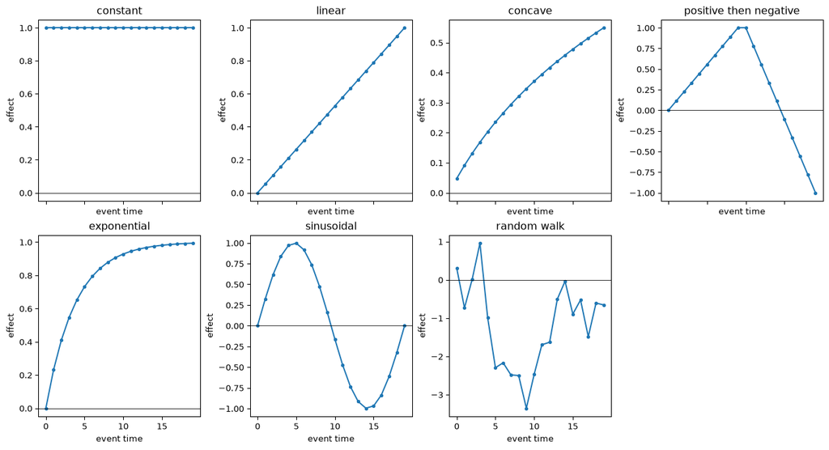

Figure 1: The seven single-cohort temporal effect alternatives.

```python
temporal_names = designs.available_ftest_temporal_designs()
figure, axes = plt.subplots(
    2,
    4,
    figsize=(13, 7),
    sharex=True,
    constrained_layout=True,
)
for axis, name in zip(axes.ravel(), temporal_names, strict=False):
    profile = designs.ftest_temporal_profile(
        name,
        config=temporal_config,
        seed=42,
    )
    axis.plot(np.arange(profile.size), profile, marker="o", markersize=3)
    axis.axhline(0.0, color="black", linewidth=0.6)
    axis.set_title(name.replace("_", " "))
    axis.set_xlabel("event time")
    axis.set_ylabel("effect")
for axis in axes.ravel()[len(temporal_names):]:
    axis.set_visible(False)
plt.show()
```

The untreated outcome contains unit effects, time effects, small unit trends, and AR(1) error. The treatment path begins at `adoption_period`.

```python
temporal_panel = designs.ftest_temporal(
    "positive_then_negative",
    config=temporal_config,
    profile_seed=42,
    seed=17,
)

print(temporal_panel.shape)
print(round(temporal_panel.true_att, 3))
```

```
(240, 35)
0.25
```

`profile_seed` fixes the random-walk alternative itself. `seed` controls the panel draw. Keeping these inputs separate prevents a change in outcome noise from changing the effect profile.

## 3 Cohort alternatives

The cohort family uses three adoption dates. Named alternatives range from a homogeneous null to large cohort differences and selection on gains.

```python
cohort_config = designs.FTestCohortConfig(n_units=240)

for name in designs.available_ftest_cohort_designs():
    profiles = designs.ftest_cohort_profiles(name, config=cohort_config)
    first_values = {
        cohort: round(float(path[0]), 2)
        for cohort, path in profiles.items()
    }
    print(name, first_values)
```

```
homogeneous {10: 0.0, 15: 0.0, 20: 0.0}
log_vs_linear_vs_sin {10: 2.0, 15: 0.69, 20: 0.84}
small_differences {10: 0.0, 15: 0.0, 20: 0.0}
large_differences {10: 0.0, 15: 0.0, 20: 0.0}
selection_on_gains {10: 0.0, 15: 0.0, 20: 0.0}
novelty_effects {10: 2.5, 15: 2.5, 20: 2.5}
activity_bias {10: 2.5, 15: 0.0, 20: 0.0}
```

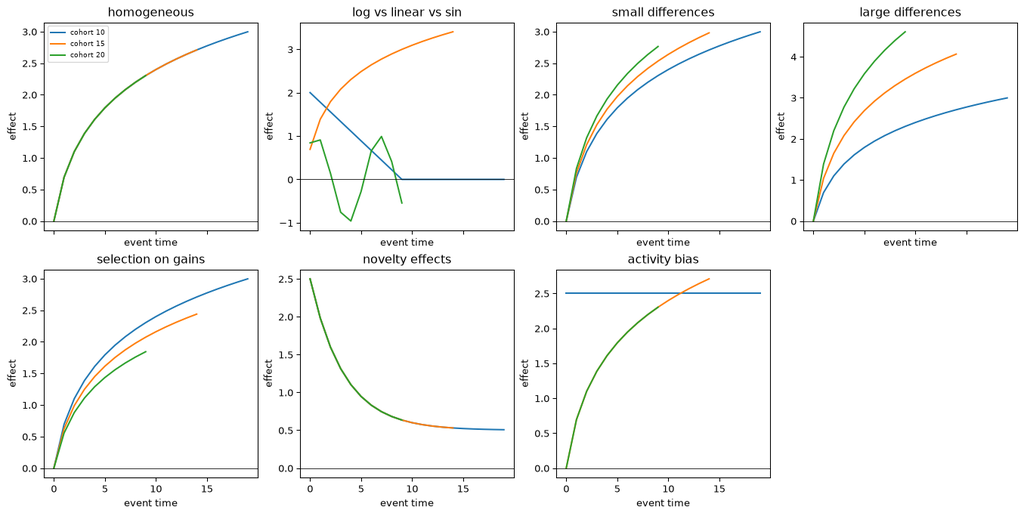

Figure 2: Cohort-specific paths for the seven effect-pattern alternatives.

```python
cohort_names = designs.available_ftest_cohort_designs()
figure, axes = plt.subplots(
    2,
    4,
    figsize=(14, 7),
    sharex=True,
    constrained_layout=True,
)
for axis, name in zip(axes.ravel(), cohort_names, strict=False):
    profiles = designs.ftest_cohort_profiles(name, config=cohort_config)
    for cohort, profile in profiles.items():
        axis.plot(
            np.arange(profile.size),
            profile,
            label=f"cohort {cohort}",
        )
    axis.axhline(0.0, color="black", linewidth=0.6)
    axis.set_title(name.replace("_", " "))
    axis.set_xlabel("event time")
    axis.set_ylabel("effect")
for axis in axes.ravel()[len(cohort_names):]:
    axis.set_visible(False)
axes.ravel()[0].legend(fontsize=7)
plt.show()
```

Run one alternative and inspect the supported cohort-event cells:

```python
cohort_panel = designs.ftest_cohort(
    "selection_on_gains",
    config=cohort_config,
    seed=17,
)

truth = cohort_panel.truth.cohort_event(event_times=(-2, -1, 0, 1, 2, 3))
for cohort in np.unique(truth["cohort"]):
    selected = truth["cohort"] == cohort
    print(
        int(cohort),
        np.round(truth["effect"][selected], 2),
        truth["supported"][selected],
    )
```

```
10 [0.   0.   0.   0.69 1.1  1.39] [ True  True  True  True  True  True]
15 [0.   0.   0.   0.62 0.99 1.25] [ True  True  True  True  True  True]
20 [0.   0.   0.   0.55 0.88 1.11] [ True  True  True  True  True  True]
```

Pre-treatment effects are zero. An unsupported cohort-event cell has `NaN` effect and `supported=False`.

## 4 Realized panel structure

The temporal design has one adoption block. The cohort design has three. The outcome heatmaps also show their different untreated dependence structures.

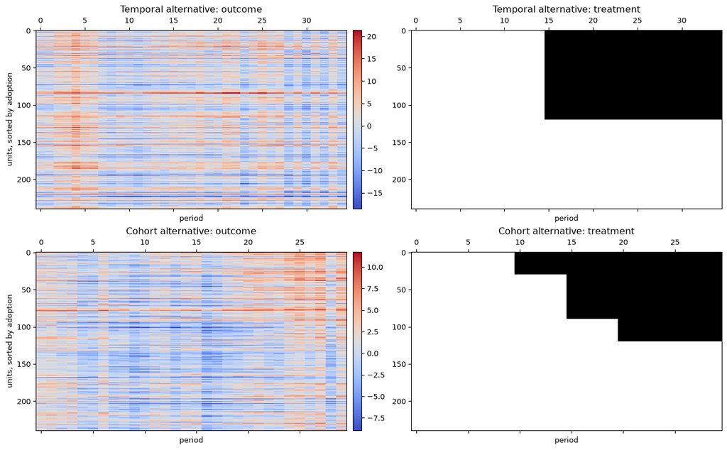

Figure 3: Observed outcomes and treatment for one temporal and one cohort-heterogeneity design.

```python
realized_panels = (
    ("Temporal alternative", temporal_panel),
    ("Cohort alternative", cohort_panel),
)
figure, axes = plt.subplots(2, 2, figsize=(13, 8), constrained_layout=True)
for row, (label, draw) in enumerate(realized_panels):
    order = np.argsort(draw.adoption_times, kind="stable")
    outcome_image = axes[row, 0].matshow(
        draw.outcome[order],
        aspect="auto",
        cmap="coolwarm",
    )
    axes[row, 1].matshow(
        draw.treatment[order],
        aspect="auto",
        cmap="Greys",
        vmin=0.0,
        vmax=1.0,
    )
    axes[row, 0].set_title(f"{label}: outcome")
    axes[row, 1].set_title(f"{label}: treatment")
    axes[row, 0].set_ylabel("units, sorted by adoption")
    figure.colorbar(outcome_image, ax=axes[row, 0], fraction=0.03, pad=0.02)
    for axis in axes[row]:
        axis.set_xlabel("period")
plt.show()
```

## 5 Build custom cohort effects

The built-in family uses the same classes available to user code. Cohort effects are specified as a map from adoption period to an event-time array.

```python
from pypanelsim import primitives

profiles = designs.ftest_cohort_profiles(
    "novelty_effects",
    config=cohort_config,
)
effect_model = primitives.CohortEventTimeEffect(profiles)

print(type(effect_model).__name__)
```

```
CohortEventTimeEffect
```

Pass this effect model to a custom `core.PanelSimulator` when the built-in untreated-outcome or assignment model is not appropriate.

## 6 Simulation-study use

A size experiment should use a homogeneous design as its null. A power experiment should vary the form and magnitude of heterogeneity. Report the exact variant, configuration, panel seed, and any profile seed. Do not refer only to “the F-test DGP”; that phrase does not identify one probability model.